# DE pri-miRNAs

Skim

2020 5 13

```r
#.libPaths(c("/home/skim/R/usr_lib", .libPaths()))
#.libPaths(c(.libPaths()))
library(Seurat, lib.loc="/data/rajewsky/shared_libs/R/")
library(tidyverse)
library(dplyr)
library(stringr)
library(ggplot2)
library(gridExtra)
```

```r
load(file="/data/rajewsky/home/skim/Microglia_Heppner/201912_10X_9sets/R_Scripts/20200210_figures_for_meeting_report_cleaned_Seurat_object_res0.8.Robj")
load(file = "/data/rajewsky/home/skim/Microglia_Heppner/201912_10X_9sets/miRNA_lncRNA/R_Scripts/20200505_pri_miRNA_dgCMatrix_Create_Seurat_with_intergenic_pri_miRNA.obj")
data9set.SO$cell_type <- data9set.SO@active.ident
```

```r
z_score_DE_genes <- function(Seurat_object, list_genes){
  for(i in c(1:9)){
  if(i == 1){
    cell_avg.df <- as.data.frame(Matrix::rowMeans(GetAssayData(object = subset(Seurat_object, subset = gemgroup %in% i), slot = 'data')))
  }
  else{
    tempcell_avg.df <- as.data.frame(Matrix::rowMeans(GetAssayData(object = subset(Seurat_object, subset = gemgroup %in% i), slot = 'data')))
  cell_avg.df <- cbind(cell_avg.df, tempcell_avg.df)
  }
}
#print("1st")
cell_avg.df$gene <- rownames(cell_avg.df)
#print("2nd")
cell_avg.df <- cell_avg.df[cell_avg.df$gene %in% list_genes, ]
#print("3rd")
cell_avg.df$gene <- NULL

# calculate z-score (high)
cell_avg_z_score.df <- as.data.frame(t(apply(cell_avg.df, 1, function(x) (x - mean(x)) / sd(x))))
return(cell_avg_z_score.df)
}
```

### 1. Neurons

#### 1-1. Subiculum

```r
Subi_DE_AD_Ctrl <- read.csv("/data/rajewsky/home/skim/Microglia_Heppner/201912_10X_9sets/miRNA_lncRNA/R_Scripts/DE_csv_files/20200513_pri_miRNA_Cell_type_DE_by_MAST_SubiculumAD_Ctrl.csv")
Subi_DE_ADp40KO_Ctrl <- read.csv("/data/rajewsky/home/skim/Microglia_Heppner/201912_10X_9sets/miRNA_lncRNA/R_Scripts/DE_csv_files/20200513_pri_miRNA_Cell_type_DE_by_MAST_SubiculumADp40KO_Ctrl.csv")
Subi_DE_AD_ADp40KO <- read.csv("/data/rajewsky/home/skim/Microglia_Heppner/201912_10X_9sets/miRNA_lncRNA/R_Scripts/DE_csv_files/20200513_pri_miRNA_Cell_type_DE_by_MAST_SubiculumAD_ADp40KO.csv")
```

Mir99ahg is one of 1429 genes associated with the alzheimer disease phenotype in GWAS datasets from the GWASdb SNP-Phenotype Associations dataset[ref](http://amp.pharm.mssm.edu/Harmonizome/gene_set/alzheimer+disease/GWASdb+SNP-Phenotype+Associations)

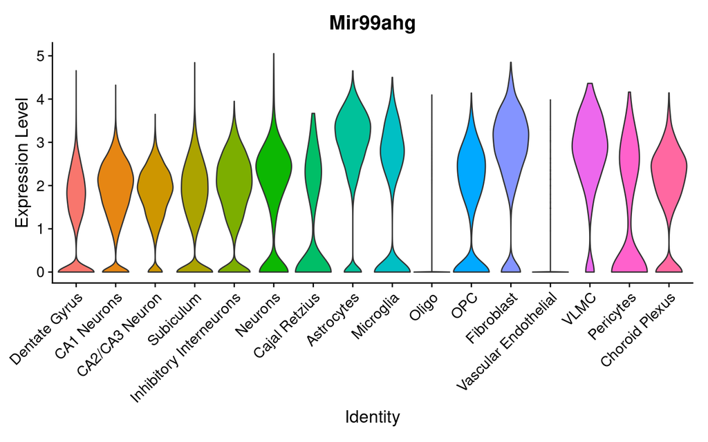

```r
VlnPlot(data9set_cleaned.SO, features = "Mir99ahg", pt.size = 0) + theme(legend.position = "none")
```

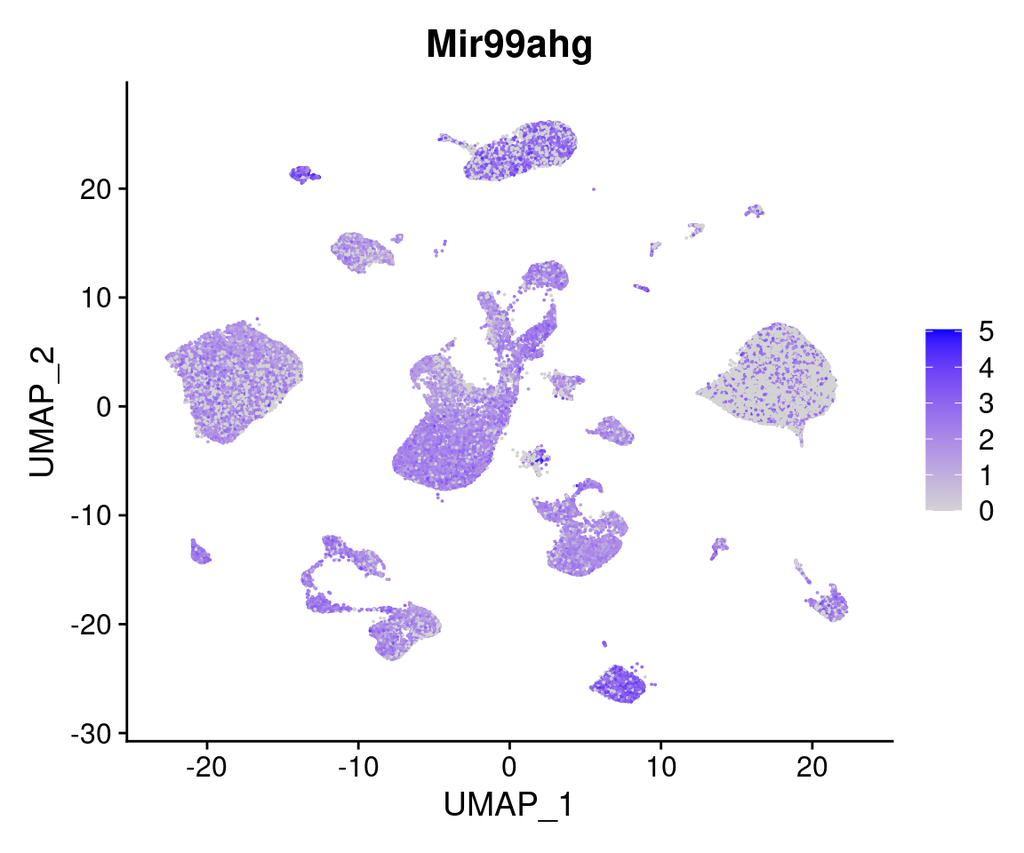

```r
FeaturePlot(data9set_cleaned.SO, features = "Mir99ahg")
```

Mir99ahg was less expressed in AD & ADp40KO compare to Ctrl

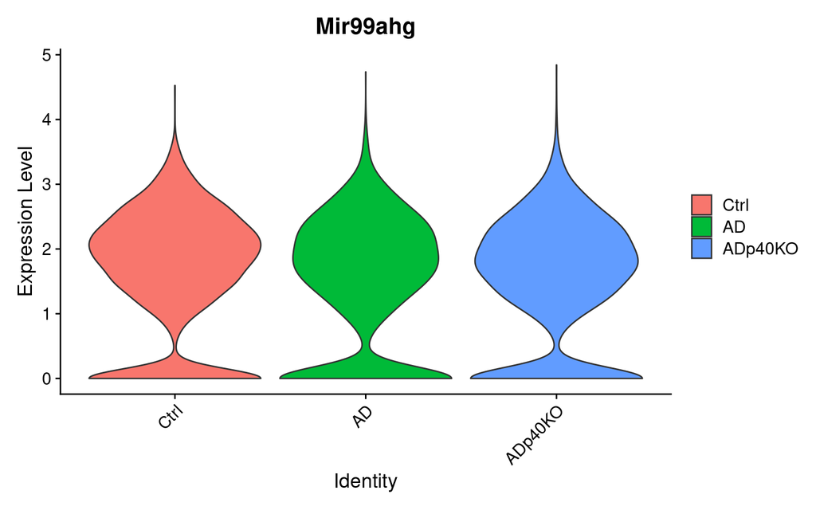

```r
data9set_subi.SO <- subset(data9set.SO, subset = cell_type %in% "Subiculum")

VlnPlot(data9set_subi.SO, features = "Mir99ahg", group.by = "sample", pt.size = 0)
```

mir-1970 is less expressed in AD & ADp40KO compare to WT.

Mir-1970 is targeting Il12b [ref](http://www.targetscan.org/cgi-bin/targetscan/mmu_72/targetscan.cgi?species=Mouse&gid=&mir_sc=&mir_c=&mir_nc=&mir_vnc=miR-1970&mirg=)

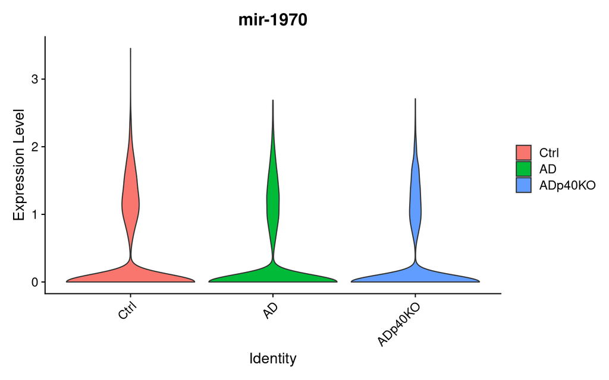

```r
VlnPlot(data9set_subi.SO, features = "mir-1970", group.by = "sample", pt.size = 0)
```

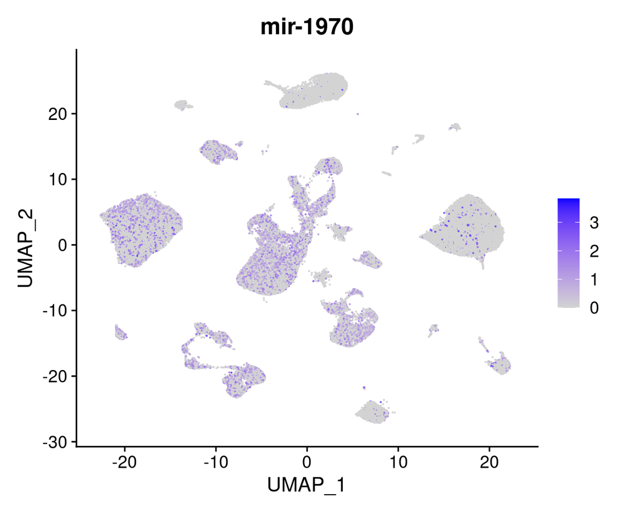

```r
FeaturePlot(data9set.SO, features = "mir-1970")
```

Mir124a-1hg is less expressed in AD and more less in ADp40KO

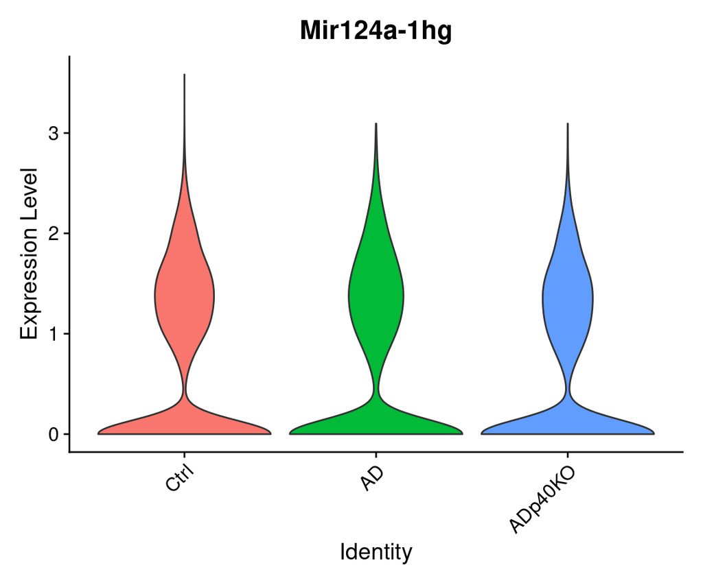

```r
VlnPlot(data9set_subi.SO, features = "Mir124a-1hg", group.by = "sample", pt.size = 0) + theme(legend.position = "none")
```

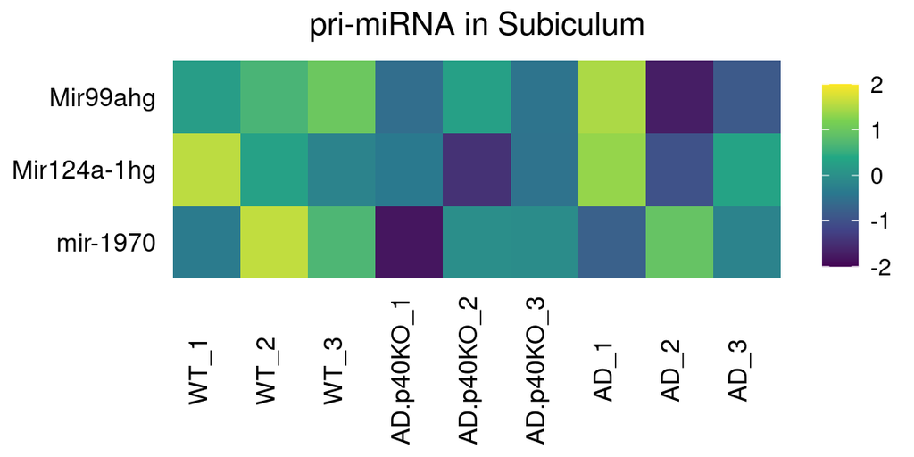

```r
list_genes <- c("mir-1970", "Mir124a-1hg", "Mir99ahg")
subi_z_score <- z_score_DE_genes(data9set_subi.SO, list_genes)
colnames(subi_z_score) <- c("WT_1", "AD.p40KO_1", "AD_1", "WT_2", "AD.p40KO_2", "AD_2", "WT_3", "AD.p40KO_3", "AD_3")

subi_z_score$gene <- rownames(subi_z_score)
#subi_z_score[,c(10,1:9)]

subi_z_score2 <- gather(subi_z_score, sample, z_score, WT_1:AD_3)

subi_z_score2$sample <- factor(subi_z_score2$sample, levels = c("WT_1", "WT_2", "WT_3", "AD.p40KO_1", "AD.p40KO_2", "AD.p40KO_3", "AD_1", "AD_2","AD_3"))

ggplot(data = subi_z_score2, mapping = aes(x = sample, y = gene, fill = z_score)) +
  ggtitle("pri-miRNA in Subiculum") +
  geom_tile()+  theme_classic() + theme(plot.title = element_text(size = 15, hjust = 0.5),
                                        axis.title.y = element_blank(),
                                         axis.title.x = element_blank(),
                                         axis.text.x = element_text(angle = 90, vjust = 0, size = 12, color = "black"),
                                         axis.text.y = element_text(size = 12, color = "black"),
                                         axis.line = element_line(color = "white"),
                                         axis.ticks = element_line(color = "white"),
                                         legend.title = element_blank(),
                                         legend.text = element_text(size = 11, color = "black")) +
 scale_fill_viridis_c(limits=c(-2, 2))
```

#### 1-2. Dentate Gyrus

In Dentate Gyrus, there were no pri-miRNA DE genes.

```r
DG_DE_AD_Ctrl <- read.csv("/data/rajewsky/home/skim/Microglia_Heppner/201912_10X_9sets/miRNA_lncRNA/R_Scripts/DE_csv_files/20200513_pri_miRNA_Cell_type_DE_by_MAST_Dentate GyrusAD_Ctrl.csv")
DG_DE_ADp40KO_Ctrl <- read.csv("/data/rajewsky/home/skim/Microglia_Heppner/201912_10X_9sets/miRNA_lncRNA/R_Scripts/DE_csv_files/20200513_pri_miRNA_Cell_type_DE_by_MAST_Dentate GyrusADp40KO_Ctrl.csv")
DG_DE_AD_ADp40KO <- read.csv("/data/rajewsky/home/skim/Microglia_Heppner/201912_10X_9sets/miRNA_lncRNA/R_Scripts/DE_csv_files/20200513_pri_miRNA_Cell_type_DE_by_MAST_Dentate GyrusAD_ADp40KO.csv")
```

#### 1-3. CA1

In CA1, there were no pri-miRNA DE genes.

```r
CA1_DE_AD_Ctrl <- read.csv("/data/rajewsky/home/skim/Microglia_Heppner/201912_10X_9sets/miRNA_lncRNA/R_Scripts/DE_csv_files/20200513_pri_miRNA_Cell_type_DE_by_MAST_CA1 NeuronsAD_Ctrl.csv")
CA1_DE_ADp40KO_Ctrl <- read.csv("/data/rajewsky/home/skim/Microglia_Heppner/201912_10X_9sets/miRNA_lncRNA/R_Scripts/DE_csv_files/20200513_pri_miRNA_Cell_type_DE_by_MAST_CA1 NeuronsADp40KO_Ctrl.csv")
CA1_DE_AD_ADp40KO <- read.csv("/data/rajewsky/home/skim/Microglia_Heppner/201912_10X_9sets/miRNA_lncRNA/R_Scripts/DE_csv_files/20200513_pri_miRNA_Cell_type_DE_by_MAST_CA1 NeuronsAD_ADp40KO.csv")
```

#### 1-3. CA2/CA3

In CA2/3, there were no pri-miRNA DE genes.

```r
CA23_DE_AD_Ctrl <- read.csv("/data/rajewsky/home/skim/Microglia_Heppner/201912_10X_9sets/miRNA_lncRNA/R_Scripts/DE_csv_files/20200513_pri_miRNA_Cell_type_DE_by_MAST_CA2_CA3_AD_Ctrl.csv")
CA23_DE_ADp40KO_Ctrl <- read.csv("/data/rajewsky/home/skim/Microglia_Heppner/201912_10X_9sets/miRNA_lncRNA/R_Scripts/DE_csv_files/20200513_pri_miRNA_Cell_type_DE_by_MAST_CA2_CA3_ADp40KO_Ctrl.csv")
CA23_DE_AD_ADp40KO <- read.csv("/data/rajewsky/home/skim/Microglia_Heppner/201912_10X_9sets/miRNA_lncRNA/R_Scripts/DE_csv_files/20200513_pri_miRNA_Cell_type_DE_by_MAST_CA2_CA3_AD_ADp40KO.csv")
```

### 2. Inhibitory interneurons

```r
IN_DE_AD_Ctrl <- read.csv("/data/rajewsky/home/skim/Microglia_Heppner/201912_10X_9sets/miRNA_lncRNA/R_Scripts/DE_csv_files/20200513_pri_miRNA_Cell_type_DE_by_MAST_Inhibitory InterneuronsAD_Ctrl.csv")
IN_DE_ADp40KO_Ctrl <- read.csv("/data/rajewsky/home/skim/Microglia_Heppner/201912_10X_9sets/miRNA_lncRNA/R_Scripts/DE_csv_files/20200513_pri_miRNA_Cell_type_DE_by_MAST_Inhibitory InterneuronsADp40KO_Ctrl.csv")
IN_DE_AD_ADp40KO <- read.csv("/data/rajewsky/home/skim/Microglia_Heppner/201912_10X_9sets/miRNA_lncRNA/R_Scripts/DE_csv_files/20200513_pri_miRNA_Cell_type_DE_by_MAST_Inhibitory InterneuronsAD_ADp40KO.csv")

data9set_IN.SO <- subset(data9set.SO, subset = cell_type %in% "Inhibitory Interneurons")
```

mir-1970 is less expressed in ADp40KO

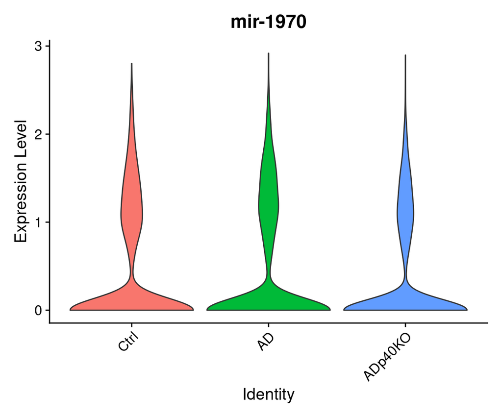

```r
VlnPlot(data9set_IN.SO, features = "mir-1970", group.by = "sample", pt.size = 0) + theme(legend.position = "none")
```

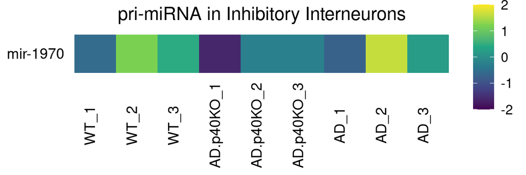

```r
list_genes <- c("mir-1970")
IN_z_score <- z_score_DE_genes(data9set_IN.SO, list_genes)
colnames(IN_z_score) <- c("WT_1", "AD.p40KO_1", "AD_1", "WT_2", "AD.p40KO_2", "AD_2", "WT_3", "AD.p40KO_3", "AD_3")

IN_z_score$gene <- rownames(IN_z_score)
#subi_z_score[,c(10,1:9)]

IN_z_score2 <- gather(IN_z_score, sample, z_score, WT_1:AD_3)

IN_z_score2$sample <- factor(IN_z_score2$sample, levels = c("WT_1", "WT_2", "WT_3", "AD.p40KO_1", "AD.p40KO_2", "AD.p40KO_3", "AD_1", "AD_2","AD_3"))

ggplot(data = IN_z_score2, mapping = aes(x = sample, y = gene, fill = z_score)) +
  ggtitle("pri-miRNA in Inhibitory Interneurons") +
  geom_tile()+  theme_classic() + theme(plot.title = element_text(size = 15, hjust = 0.5),
                                        axis.title.y = element_blank(),
                                         axis.title.x = element_blank(),
                                         axis.text.x = element_text(angle = 90, vjust = 0, size = 12, color = "black"),
                                         axis.text.y = element_text(size = 12, color = "black"),
                                         axis.line = element_line(color = "white"),
                                         axis.ticks = element_line(color = "white"),
                                         legend.title = element_blank(),
                                         legend.text = element_text(size = 11, color = "black")) +
 scale_fill_viridis_c(limits=c(-2, 2))
```

### 3. Astrocytes

```r
AS_DE_AD_Ctrl <- read.csv("/data/rajewsky/home/skim/Microglia_Heppner/201912_10X_9sets/miRNA_lncRNA/R_Scripts/DE_csv_files/20200513_pri_miRNA_Cell_type_DE_by_MAST_AstrocytesAD_Ctrl.csv")
AS_DE_ADp40KO_Ctrl <- read.csv("/data/rajewsky/home/skim/Microglia_Heppner/201912_10X_9sets/miRNA_lncRNA/R_Scripts/DE_csv_files/20200513_pri_miRNA_Cell_type_DE_by_MAST_AstrocytesADp40KO_Ctrl.csv")
AS_DE_AD_ADp40KO <- read.csv("/data/rajewsky/home/skim/Microglia_Heppner/201912_10X_9sets/miRNA_lncRNA/R_Scripts/DE_csv_files/20200513_pri_miRNA_Cell_type_DE_by_MAST_AstrocytesAD_ADp40KO.csv")
```

Mir99ahg is upregulated only in ADp40KO in astrocytes

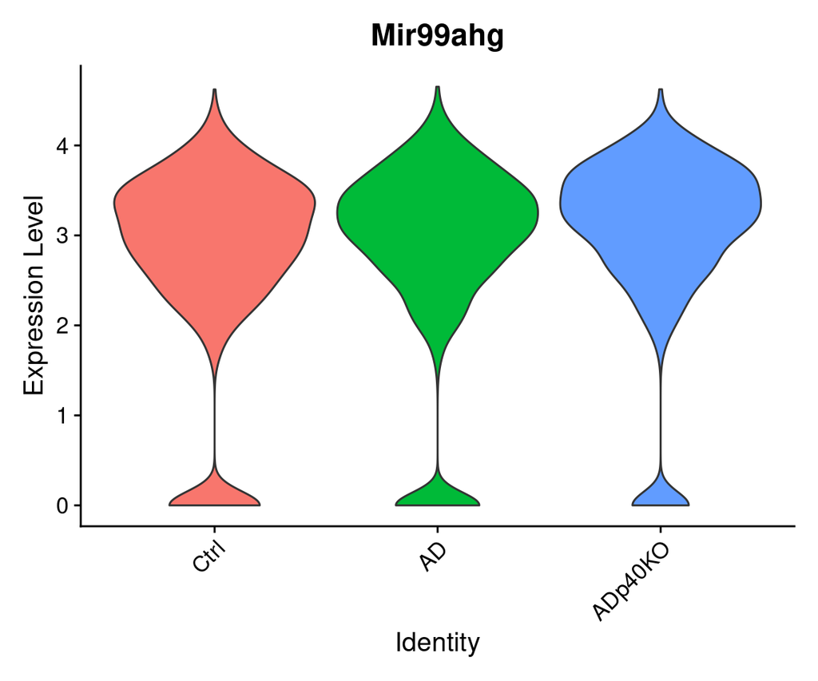

```r
data9set_AS.SO <- subset(data9set.SO, subset = cell_type %in% "Astrocytes")

VlnPlot(data9set_AS.SO, features = "Mir99ahg", group.by = "sample", pt.size = 0) + theme(legend.position = "none")
```

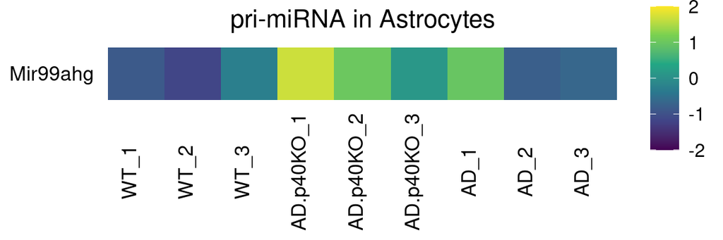

```r
list_genes <- c("Mir99ahg")
AS_z_score <- z_score_DE_genes(data9set_AS.SO, list_genes)
colnames(AS_z_score) <- c("WT_1", "AD.p40KO_1", "AD_1", "WT_2", "AD.p40KO_2", "AD_2", "WT_3", "AD.p40KO_3", "AD_3")

AS_z_score$gene <- rownames(AS_z_score)
#subi_z_score[,c(10,1:9)]

AS_z_score2 <- gather(AS_z_score, sample, z_score, WT_1:AD_3)

AS_z_score2$sample <- factor(AS_z_score2$sample, levels = c("WT_1", "WT_2", "WT_3", "AD.p40KO_1", "AD.p40KO_2", "AD.p40KO_3", "AD_1", "AD_2","AD_3"))

ggplot(data = AS_z_score2, mapping = aes(x = sample, y = gene, fill = z_score)) +
  ggtitle("pri-miRNA in Astrocytes") +
  geom_tile()+  theme_classic() + theme(plot.title = element_text(size = 15, hjust = 0.5),
                                        axis.title.y = element_blank(),
                                         axis.title.x = element_blank(),
                                         axis.text.x = element_text(angle = 90, vjust = 0, size = 12, color = "black"),
                                         axis.text.y = element_text(size = 12, color = "black"),
                                         axis.line = element_line(color = "white"),
                                         axis.ticks = element_line(color = "white"),
                                         legend.title = element_blank(),
                                         legend.text = element_text(size = 11, color = "black")) +
 scale_fill_viridis_c(limits=c(-2, 2))
```

### 4. Oligo

In oligodendrocytes, there were no pri-miRNA DE genes.

```r
OL_DE_AD_Ctrl <- read.csv("/data/rajewsky/home/skim/Microglia_Heppner/201912_10X_9sets/miRNA_lncRNA/R_Scripts/DE_csv_files/20200513_pri_miRNA_Cell_type_DE_by_MAST_OligoAD_Ctrl.csv")
OL_DE_ADp40KO_Ctrl <- read.csv("/data/rajewsky/home/skim/Microglia_Heppner/201912_10X_9sets/miRNA_lncRNA/R_Scripts/DE_csv_files/20200513_pri_miRNA_Cell_type_DE_by_MAST_OligoADp40KO_Ctrl.csv")
OL_DE_AD_ADp40KO <- read.csv("/data/rajewsky/home/skim/Microglia_Heppner/201912_10X_9sets/miRNA_lncRNA/R_Scripts/DE_csv_files/20200513_pri_miRNA_Cell_type_DE_by_MAST_OligoAD_ADp40KO.csv")
```

### 5. Microglia

```r
MG_DE_AD_Ctrl <- read.csv("/data/rajewsky/home/skim/Microglia_Heppner/201912_10X_9sets/miRNA_lncRNA/R_Scripts/DE_csv_files/20200513_pri_miRNA_Cell_type_DE_by_MAST_MicrogliaAD_Ctrl.csv")
MG_DE_ADp40KO_Ctrl <- read.csv("/data/rajewsky/home/skim/Microglia_Heppner/201912_10X_9sets/miRNA_lncRNA/R_Scripts/DE_csv_files/20200513_pri_miRNA_Cell_type_DE_by_MAST_MicrogliaADp40KO_Ctrl.csv")
MG_DE_AD_ADp40KO <- read.csv("/data/rajewsky/home/skim/Microglia_Heppner/201912_10X_9sets/miRNA_lncRNA/R_Scripts/DE_csv_files/20200513_pri_miRNA_Cell_type_DE_by_MAST_MicrogliaAD_ADp40KO.csv")

data9set_MG.SO <- subset(data9set.SO, subset = cell_type %in% "Microglia")
```

mir-146a is less expressed in AD compare to WT and ADp40KO

In the literature, In the brain tissues of cT2DM rats, it was observed that the expressions of inflammatory mediators (COX-2, TNF-α, IL-1β) and oxidative stress indicators including MDA and p22phox were elevated, which were negatively correlated with the expression of miR-146a. [ref](https://www.ncbi.nlm.nih.gov/pmc/articles/PMC5960742/) [ref2](https://www.nature.com/articles/srep38339)

A reduced effect of miR-146a on the abnormal activation of microglia in the hippocampus indicates that miR-146a is a potential therapeutic target of POCD [ref](https://www.frontiersin.org/articles/10.3389/fnmol.2019.00125/full)

MicroRNA-146a protects against cognitive decline induced by surgical trauma by suppressing hippocampal neuroinflammation in mice.[ref](https://www.ncbi.nlm.nih.gov/pubmed/30685530)

miR-146a-3p targeting Il12rb1 [ref](http://www.targetscan.org/cgi-bin/targetscan/mmu_72/targetscan.cgi?species=Mouse&mir_vnc=miR-146a-3p)

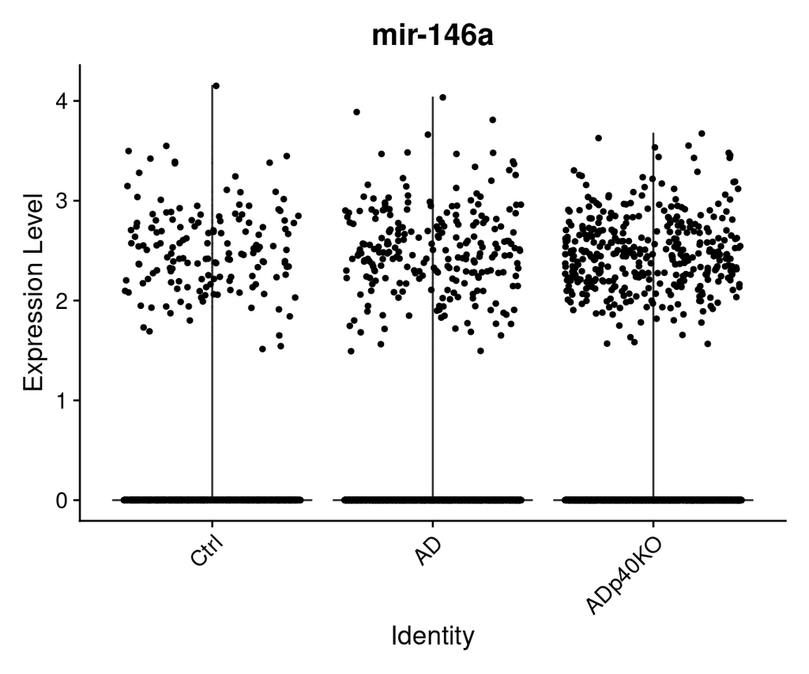

```r
VlnPlot(data9set_MG.SO, features = "mir-146a", group.by = "sample") + theme(legend.position = "none")
```

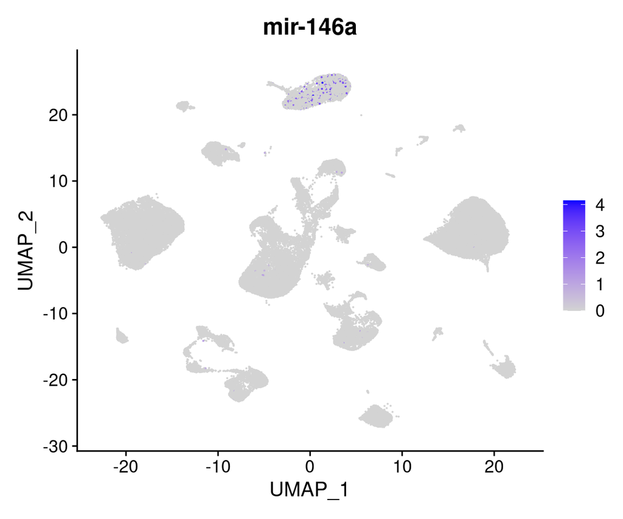

```r
FeaturePlot(data9set.SO, features = "mir-146a")
```

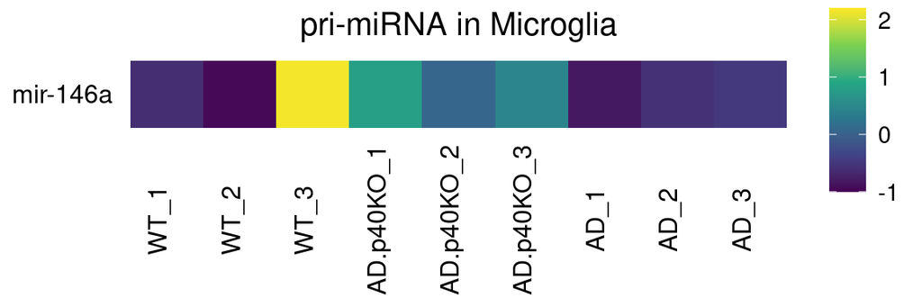

```r
list_genes <- c("mir-146a")
MG_z_score <- z_score_DE_genes(data9set_MG.SO, list_genes)
colnames(MG_z_score) <- c("WT_1", "AD.p40KO_1", "AD_1", "WT_2", "AD.p40KO_2", "AD_2", "WT_3", "AD.p40KO_3", "AD_3")

MG_z_score$gene <- rownames(MG_z_score)
#subi_z_score[,c(10,1:9)]

MG_z_score2 <- gather(MG_z_score, sample, z_score, WT_1:AD_3)

MG_z_score2$sample <- factor(MG_z_score2$sample, levels = c("WT_1", "WT_2", "WT_3", "AD.p40KO_1", "AD.p40KO_2", "AD.p40KO_3", "AD_1", "AD_2","AD_3"))

ggplot(data = MG_z_score2, mapping = aes(x = sample, y = gene, fill = z_score)) +
  ggtitle("pri-miRNA in Microglia") +
  geom_tile()+  theme_classic() + theme(plot.title = element_text(size = 15, hjust = 0.5),
                                        axis.title.y = element_blank(),
                                         axis.title.x = element_blank(),
                                         axis.text.x = element_text(angle = 90, vjust = 0, size = 12, color = "black"),
                                         axis.text.y = element_text(size = 12, color = "black"),
                                         axis.line = element_line(color = "white"),
                                         axis.ticks = element_line(color = "white"),
                                         legend.title = element_blank(),
                                         legend.text = element_text(size = 11, color = "black")) +
 scale_fill_viridis_c(limits=c(-1, 2.2))
```

### 6. OPC

```r
OPC_DE_AD_Ctrl <- read.csv("/data/rajewsky/home/skim/Microglia_Heppner/201912_10X_9sets/miRNA_lncRNA/R_Scripts/DE_csv_files/20200513_pri_miRNA_Cell_type_DE_by_MAST_OPCAD_Ctrl.csv")
OPC_DE_ADp40KO_Ctrl <- read.csv("/data/rajewsky/home/skim/Microglia_Heppner/201912_10X_9sets/miRNA_lncRNA/R_Scripts/DE_csv_files/20200513_pri_miRNA_Cell_type_DE_by_MAST_OPCADp40KO_Ctrl.csv")
OPC_DE_AD_ADp40KO <- read.csv("/data/rajewsky/home/skim/Microglia_Heppner/201912_10X_9sets/miRNA_lncRNA/R_Scripts/DE_csv_files/20200513_pri_miRNA_Cell_type_DE_by_MAST_OPCAD_ADp40KO.csv")

data9set_OPC.SO <- subset(data9set.SO, subset = cell_type %in% "OPC")
```

Check mir-1970, Mir124a-1hg, Mir9-3hg, Mir99ahg

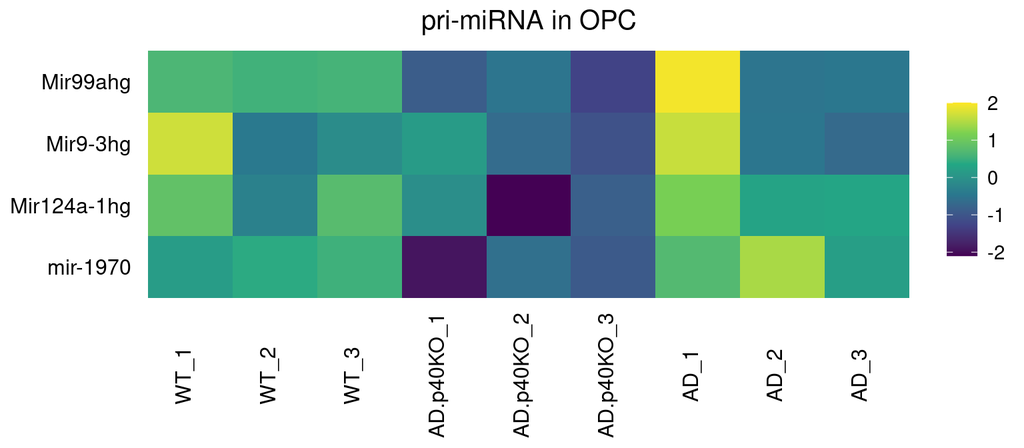

```r
list_genes <- c("mir-1970", "Mir124a-1hg", "Mir9-3hg", "Mir99ahg")
OPC_z_score <- z_score_DE_genes(data9set_OPC.SO, list_genes)
colnames(OPC_z_score) <- c("WT_1", "AD.p40KO_1", "AD_1", "WT_2", "AD.p40KO_2", "AD_2", "WT_3", "AD.p40KO_3", "AD_3")

OPC_z_score$gene <- rownames(OPC_z_score)
#OPC_z_score[,c(10,1:9)]

OPC_z_score2 <- gather(OPC_z_score, sample, z_score, WT_1:AD_3)

OPC_z_score2$sample <- factor(OPC_z_score2$sample, levels = c("WT_1", "WT_2", "WT_3", "AD.p40KO_1", "AD.p40KO_2", "AD.p40KO_3", "AD_1", "AD_2","AD_3"))

ggplot(data = OPC_z_score2, mapping = aes(x = sample, y = gene, fill = z_score)) +
  ggtitle("pri-miRNA in OPC") +
  geom_tile()+  theme_classic() + theme(plot.title = element_text(size = 15, hjust = 0.5),
                                        axis.title.y = element_blank(),
                                         axis.title.x = element_blank(),
                                         axis.text.x = element_text(angle = 90, vjust = 0, size = 12, color = "black"),
                                         axis.text.y = element_text(size = 12, color = "black"),
                                         axis.line = element_line(color = "white"),
                                         axis.ticks = element_line(color = "white"),
                                         legend.title = element_blank(),
                                         legend.text = element_text(size = 11, color = "black")) +
 scale_fill_viridis_c(limits=c(-2.1, 2))
```